# Quiz 1: Part 2

## Part 2: Coding in action

### Instructions

Please answer these questions in R using whatever syntax makes sense to you. Feel free to use the R help pages and/or notes from class.

**If you use Google or ChatGPT etc. to help you get to an answer, please note so on your answer**

Step 1. ARE YOU IN A BRANCH?????  
Step 2. Save this file as lastname_quiz.qmd in the same quiz folder.  
Step 3. Once you are done, click “render” above. This will create the .html file that I will evaluate.  
Step 4. Stage and commit your changes, push to your github.  
Step 5. Submit a pull request. If github warns you of conflicts please try and fix them before submitting your pull request (did you rename the file??? ).  
(Step 6. In case of utter disaster, email Sabrina your .html file.)

```r
# load packages and data
library(ggplot2)
library(dslabs)
library(dplyr)
library(tidyverse)
```

#### Load your data:

Load the *swallows.csv* into R, call it swallows. This data frame lists results of an experiment on tree swallows. Each row is a nest. Nests were put into one of two **treatments**: simulated predation (predator), or control (control). Along with treatment you have the following columns:  
**nest_fate** = whether the nest fledged any young or whether they all died  
**brood** = number of nestlings  
**n_fledged** = number of nestlings that fledged.

You also have a separate data frame called *brightness.csv* where each row lists the plumage brightness (a sexual signal) for the female at each nest. Load this one up too.

```r
# Type your answer in this box using R code
swallows <- read.csv("swallows.csv")

head(swallows)
```

```
  nestbox treatment brood n_fledged
1   2_124   Control     6         2
2    2_22   Control     5         5
3   2_109 Predation     5         2
4     2_8   Control     5         3
5    2_12   Control     6         6
6    2_14 Predation     3         2
```

```r
colnames(swallows)
```

```
[1] "nestbox"   "treatment" "brood"     "n_fledged"
```

```r
#I don't think this data frame has the nest_fate column

brightness <- read.csv("brightness.csv")

head(brightness)
```

```
  brightness nestbox
1       35.3   1_104
2       50.6    1_12
3       33.9   1_121
4       42.4   1_123
5       53.6    1_17
6       56.0    1_62
```

```r
# Google? y/n
#no
```

#### Wrangle your data

```r
#Answer
bright_swallows <- left_join(swallows, brightness, by = "nestbox")

#I checked this join using the function head and colnames
head(bright_swallows)
```

```
  nestbox treatment brood n_fledged brightness
1   2_124   Control     6         2       58.4
2    2_22   Control     5         5       57.7
3   2_109 Predation     5         2         NA
4     2_8   Control     5         3       55.7
5    2_12   Control     6         6       58.6
6    2_14 Predation     3         2       54.2
```

```r
colnames(bright_swallows)
```

```
[1] "nestbox"    "treatment"  "brood"      "n_fledged"  "brightness"
```

```r
#Google?
#no
```

Inspect your combined data frame. Do some sort of quick sanity check on each column to catch any obvious entry errors. Correct as necessary

```r
# Answer
class(bright_swallows$brightness)
```

```
[1] "numeric"
```

```r
class(bright_swallows$brood)
```

```
[1] "integer"
```

```r
class(bright_swallows$n_fledged)
```

```
[1] "integer"
```

```r
all(bright_swallows$treatment %in% c("Control", "Predation"))
```

```
[1] TRUE
```

```r
summary(bright_swallows)
```

```
   nestbox           treatment             brood         n_fledged
 Length:42          Length:42          Min.   :0.000   Min.   :0.000
 Class :character   Class :character   1st Qu.:4.000   1st Qu.:0.000
 Mode  :character   Mode  :character   Median :5.000   Median :2.000
                                       Mean   :4.381   Mean   :2.167
                                       3rd Qu.:5.750   3rd Qu.:4.000
                                       Max.   :7.000   Max.   :6.000

   brightness
 Min.   :33.9
 1st Qu.:47.1
 Median :53.3
 Mean   :51.2
 3rd Qu.:57.0
 Max.   :68.0
 NA's   :1
```

```r
bright_swallows <- bright_swallows %>%
  filter(!brightness %in% c(NA))

# Google y/n
#no
```

Create a new column called prop_fledged that contains the proportion of nestlings that fledged from each nest.

```r
#Answer
bright_swallows <- bright_swallows %>%
  mutate(prop_fledged = n_fledged/brood)

head(bright_swallows)
```

```
  nestbox treatment brood n_fledged brightness prop_fledged
1   2_124   Control     6         2       58.4    0.3333333
2    2_22   Control     5         5       57.7    1.0000000
3     2_8   Control     5         3       55.7    0.6000000
4    2_12   Control     6         6       58.6    1.0000000
5    2_14 Predation     3         2       54.2    0.6666667
6    2_34   Control     4         4       41.5    1.0000000
```

```r
class(bright_swallows$prop_fledged)
```

```
[1] "numeric"
```

```r
# Google? y/n
#no
```

#### Explore the data

What was the mean proportion of nestlings fledged in each treatment?

```r
# Answer
bright_swallows %>%
  filter(treatment == "Control") %>%
  summarise(mean_prop_control = mean(prop_fledged, na.rm = TRUE))
```

```
  mean_prop_control
1         0.7055556
```

```r
#the mean proportion of nestlings fledged in the control treatment is 0.7055556

bright_swallows %>%
  filter(treatment == "Predation") %>%
  summarise(mean_prop_predation = mean(prop_fledged, na.rm = TRUE))
```

```
  mean_prop_predation
1           0.3316667
```

```r
#the mean proportion of nestlings fledged in the predation treatment is 0.3316667

# Google? y/n
#yes
```

Create a plot showing fledging success differences between treatments

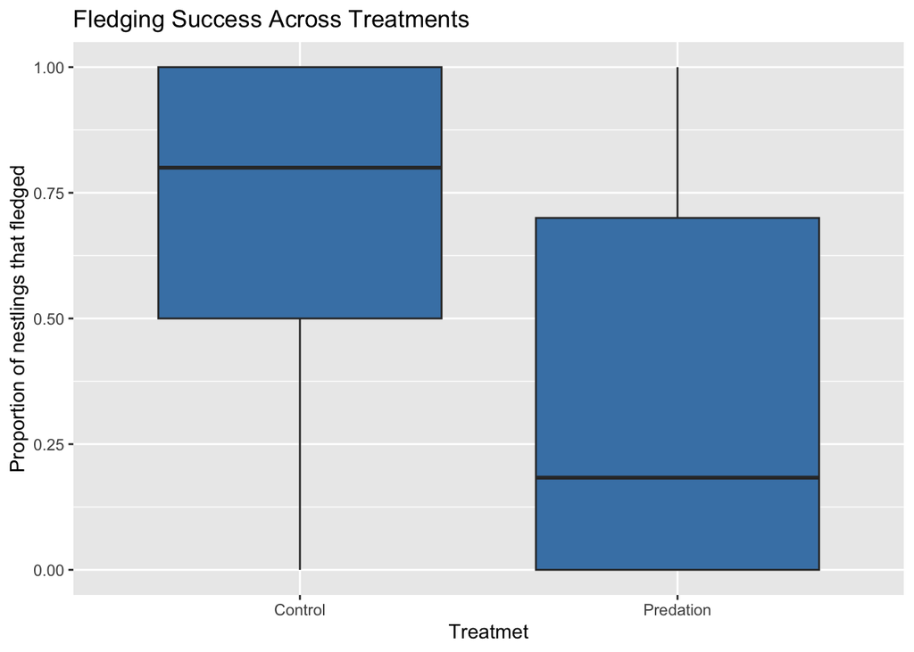

```r
# Answer
bright_swallows %>%
  ggplot(aes(x=treatment,y=prop_fledged)) +
  geom_boxplot(fill="steelblue") +
  labs(title = "Fledging Success Across Treatments", x = "Treatmet", y = "Proportion of nestlings that fledged")
```

```r
theme_minimal() +
  theme(axis.text.x = element_text(size=12),
        axis.test.y = element_text(size=12),
        plot.title = element_text(size=14), face="bold")
```

[output not shown]

[output cut: 240 more lines]

[output not shown]

```r
# Google? y/n
#no
```

Is there any evidence that female brightness influenced fledging success? Create a plot to visually investigate this question.

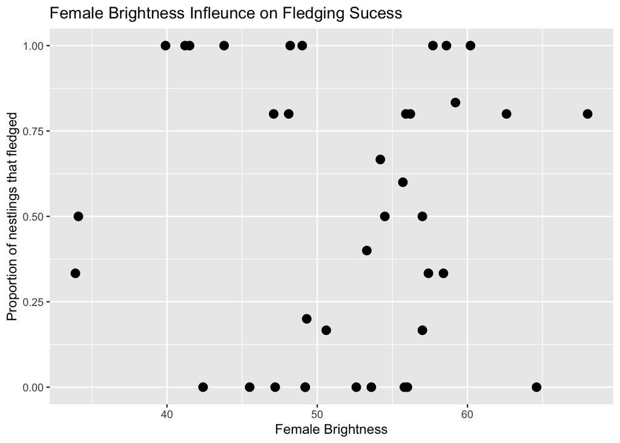

```r
# Answer
bright_swallows %>% ggplot(aes(x=brightness,y=prop_fledged)) +
  geom_point(size = 3) +
  labs(title = "Female Brightness Infleunce on Fledging Sucess", x = "Female Brightness", y = "Proportion of nestlings that fledged")
```

```r
theme_minimal() +
  theme(axis.text.x = element_text(size=12),
        axis.test.y = element_text(size=12),
        plot.title = element_text(size=14), face="bold")
```

[output not shown]

[output cut: 240 more lines]

[output not shown]

```r
#based on the randomness of the plot, female brightness does not infleunce fledging success

# Google? y/n
#no
```